# RNA-seq workflow: gene-level exploratory analysis and differential expression

# Using Salmon and tximeta

```r
# Getting the full path to the directory where airway package stored data analyzed via Salmon

dir <- system.file("extdata", package="airway", mustWork=TRUE)

list.files(dir)
```

```
##  [1] "GSE52778_series_matrix.txt"        "Homo_sapiens.GRCh37.75_subset.gtf"
##  [3] "quants"                            "sample_table.csv"
##  [5] "SraRunInfo_SRP033351.csv"          "SRR1039508_subset.bam"
##  [7] "SRR1039509_subset.bam"             "SRR1039512_subset.bam"
##  [9] "SRR1039513_subset.bam"             "SRR1039516_subset.bam"
## [11] "SRR1039517_subset.bam"             "SRR1039520_subset.bam"
## [13] "SRR1039521_subset.bam"
```

```r
list.files(file.path(dir, "quants"))
```

```
## [1] "SRR1039508" "SRR1039509"
```

```r
#Read the csv.file
csvfile <- (file= file.path(dir, "sample_table.csv"))

coldata <- read_csv(csvfile)
#Using two samples from salmon quantitation
coldata <- coldata[1:2,]
coldata$names <- coldata$Run
coldata$files <- file.path(dir, "quants", coldata$names, "quant.sf.gz")
file.exists(coldata$files)
```

```
## [1] TRUE TRUE
```

```r
#Using taximeta library to to import quantifications

se <- tximeta(coldata)
```

```
## importing quantifications
```

```
## reading in files with read_tsv
```

```
## 1 2
## found matching transcriptome:
## [ GENCODE - Homo sapiens - release 29 ]
## building TxDb with 'GenomicFeatures' package
## Import genomic features from the file as a GRanges object ... OK
## Prepare the 'metadata' data frame ... OK
## Make the TxDb object ...
```

```
## OK
## generating transcript ranges
## fetching genome info for GENCODE
```

```r
dim(se)
```

```
## [1] 205870      2
```

```r
head(rownames(se))
```

```
## [1] "ENST00000456328.2" "ENST00000450305.2" "ENST00000488147.1"
## [4] "ENST00000619216.1" "ENST00000473358.1" "ENST00000469289.1"
```

```r
#Summarizing the transcript level quantitation to the gene level

gse <- summarizeToGene(se)
```

```
## loading existing TxDb created: 2020-10-17 15:00:38
## obtaining transcript-to-gene mapping from database
## generating gene ranges
## summarizing abundance
## summarizing counts
## summarizing length
```

```r
dim(gse)
```

```
## [1] 58294     2
```

```r
head(rownames(gse))
```

```
## [1] "ENSG00000000003.14" "ENSG00000000005.5"  "ENSG00000000419.12"
## [4] "ENSG00000000457.13" "ENSG00000000460.16" "ENSG00000000938.12"
```

```r
data(gse)
gse
```

```
## class: RangedSummarizedExperiment
## dim: 58294 8
## metadata(6): tximetaInfo quantInfo ... txomeInfo txdbInfo
## assays(3): counts abundance length
## rownames(58294): ENSG00000000003.14 ENSG00000000005.5 ...
##   ENSG00000285993.1 ENSG00000285994.1
## rowData names(1): gene_id
## colnames(8): SRR1039508 SRR1039509 ... SRR1039520 SRR1039521
## colData names(3): names donor condition
```

```r
assayNames(gse)
```

```
## [1] "counts"    "abundance" "length"
```

## SummarizedExperiment

```r
# Retrieving the matrix of counts in  SummarizedExperiments objects called gse
head(assay(gse),3)
```

```
##                    SRR1039508 SRR1039509 SRR1039512 SRR1039513 SRR1039516
## ENSG00000000003.14    708.164    467.962    900.992    424.368   1188.295
## ENSG00000000005.5       0.000      0.000      0.000      0.000      0.000
## ENSG00000000419.12    455.000    510.000    604.000    352.000    583.000
##                    SRR1039517 SRR1039520 SRR1039521
## ENSG00000000003.14   1090.668    805.929    599.337
## ENSG00000000005.5       0.000      0.000      0.000
## ENSG00000000419.12    773.999    409.999    499.000
```

```r
colSums(assay(gse))
```

```
## SRR1039508 SRR1039509 SRR1039512 SRR1039513 SRR1039516 SRR1039517 SRR1039520
##   21100805   19298584   26145537   15688246   25268618   31891456   19683767
## SRR1039521
##   21813903
```

```r
# Retrieving the information about genomic ranges in  SummarizedExperiments objects called gse
rowRanges(gse)
```

```
## GRanges object with 58294 ranges and 1 metadata column:
##                      seqnames              ranges strand |            gene_id
##                         <Rle>           <IRanges>  <Rle> |        <character>
##   ENSG00000000003.14     chrX 100627109-100639991      - | ENSG00000000003.14
##    ENSG00000000005.5     chrX 100584802-100599885      + |  ENSG00000000005.5
##   ENSG00000000419.12    chr20   50934867-50958555      - | ENSG00000000419.12
##   ENSG00000000457.13     chr1 169849631-169894267      - | ENSG00000000457.13
##   ENSG00000000460.16     chr1 169662007-169854080      + | ENSG00000000460.16
##                  ...      ...                 ...    ... .                ...
##    ENSG00000285990.1    chr14   19244904-19269380      - |  ENSG00000285990.1
##    ENSG00000285991.1     chr6 149817937-149896011      - |  ENSG00000285991.1
##    ENSG00000285992.1     chr8   47129262-47132628      + |  ENSG00000285992.1
##    ENSG00000285993.1    chr18   46409197-46410645      - |  ENSG00000285993.1
##    ENSG00000285994.1    chr10   12563151-12567351      + |  ENSG00000285994.1
##   -------
##   seqinfo: 25 sequences (1 circular) from hg38 genome
```

```r
# Retrieving metadata about sequences in RowRanges above
seqinfo(rowRanges(gse))
```

```
## Seqinfo object with 25 sequences (1 circular) from hg38 genome:
##   seqnames seqlengths isCircular genome
##   chr1      248956422      FALSE   hg38
##   chr2      242193529      FALSE   hg38
##   chr3      198295559      FALSE   hg38
##   chr4      190214555      FALSE   hg38
##   chr5      181538259      FALSE   hg38
##   ...             ...        ...    ...
##   chr21      46709983      FALSE   hg38
##   chr22      50818468      FALSE   hg38
##   chrX      156040895      FALSE   hg38
##   chrY       57227415      FALSE   hg38
##   chrM          16569       TRUE   hg38
```

```r
# Retrieving the dataframe/ sample information given to tximeta function for importing the quantitation data


colData(gse)
```

```
## DataFrame with 8 rows and 3 columns
##                 names    donor     condition
##              <factor> <factor>      <factor>
## SRR1039508 SRR1039508  N61311  Untreated
## SRR1039509 SRR1039509  N61311  Dexamethasone
## SRR1039512 SRR1039512  N052611 Untreated
## SRR1039513 SRR1039513  N052611 Dexamethasone
## SRR1039516 SRR1039516  N080611 Untreated
## SRR1039517 SRR1039517  N080611 Dexamethasone
## SRR1039520 SRR1039520  N061011 Untreated
## SRR1039521 SRR1039521  N061011 Dexamethasone
```

```r
# Examine the columns of colData of gse
gse$donor
```

```
## [1] N61311  N61311  N052611 N052611 N080611 N080611 N061011 N061011
## Levels: N052611 N061011 N080611 N61311
```

```r
gse$condition
```

```
## [1] Untreated     Dexamethasone Untreated     Dexamethasone Untreated
## [6] Dexamethasone Untreated     Dexamethasone
## Levels: Untreated Dexamethasone
```

```r
# Renaming the conditions
gse$cell <- gse$donor
gse$dex <- gse$condition
levels(gse$dex)
```

```
## [1] "Untreated"     "Dexamethasone"
```

```r
levels(gse$dex) <- c("untrt", "trt")
levels(gse$dex)
```

```
## [1] "untrt" "trt"
```

# Design formula

To find the differential expression of treatmentrs; untreated & dexamethasone, we use the formula ~condition. ‘condition’ is a column in colData.

To find the differential expression of treatment in different cell lines we use ~cell+dex

relevel() in library(magrittr)- The levels of a factor are re-ordered so that the level specified by ref is first and the others are moved down.

```r
#library(magrittr)
gse$dex %<>% relevel(ref = "untrt")

# The above line is same as
gse$dex <- relevel(gse$dex, ref="untrt")
```

Find number of fragments mapped to genes by Salmon

```r
round(colSums(assay(gse))/10e6, 1)
```

```
## SRR1039508 SRR1039509 SRR1039512 SRR1039513 SRR1039516 SRR1039517 SRR1039520
##        2.1        1.9        2.6        1.6        2.5        3.2        2.0
## SRR1039521
##        2.2
```

Constructing a DESeqDataSet object from annotated SummarizedExperiment object

DESeqDataSet()- The DESeqDataSet class enforces non-negative integer values in the “counts” matrix stored as the first element in the assay list. In addition, a formula which specifies the design of the experiment must be provided.

```r
# library(DESeq2)
dds <- DESeqDataSet(gse, design = ~cell+dex)
```

```
## using counts and average transcript lengths from tximeta
```

Building an DESeqDataset (**if we do not have a SummarizedExperiment object** . In practise count matrix is read from a file or generated by featureCounts from Rsubread)

1. Generae a a table with fragment counts

```r
countdata <- countdata<-round(gse@assays@data@listData[["counts"]])

head(countdata,3)
```

```
##                    SRR1039508 SRR1039509 SRR1039512 SRR1039513 SRR1039516
## ENSG00000000003.14        708        468        901        424       1188
## ENSG00000000005.5           0          0          0          0          0
## ENSG00000000419.12        455        510        604        352        583
##                    SRR1039517 SRR1039520 SRR1039521
## ENSG00000000003.14       1091        806        599
## ENSG00000000005.5           0          0          0
## ENSG00000000419.12        774        410        499
```

2. Generate a table with information about samples

```r
coldata <- colData(gse)
```

3. Generating the DESeqDataSet

```r
DESeqDataSetFromMatrix(countData = countdata,
                       colData = coldata,
                       design = ~cell+dex)
```

```
## class: DESeqDataSet
## dim: 58294 8
## metadata(1): version
## assays(1): counts
## rownames(58294): ENSG00000000003.14 ENSG00000000005.5 ...
##   ENSG00000285993.1 ENSG00000285994.1
## rowData names(0):
## colnames(8): SRR1039508 SRR1039509 ... SRR1039520 SRR1039521
## colData names(5): names donor condition cell dex
```

## Pre-filtering data set

Filter the rows with counts greater than zeros, or one accross all samples

counts()- The counts slot holds the count data as a matrix of non-negative integer count values, one row for each observational unit (gene or the like), and one column for each sample.

```r
nrow(dds)
```

```
## [1] 58294
```

```r
keep <- rowSums(counts(object = dds))>1
dds <-dds[keep,]
nrow(dds)
```

```
## [1] 31604
```

Filter the rows with at least 3 samples have a count of 10 or higher

```r
keep <- rowSums(counts(object=dds)>=10)>=3

dds <- dds[keep,]
nrow(dds)
```

```
## [1] 17213
```

## The variance stabilizing transformation and the rlog

For RNA-seq counts variance grows with mean. (Such data principal component analysis (PCA) of such data depends on highest counts as they show highest differences between samples.)

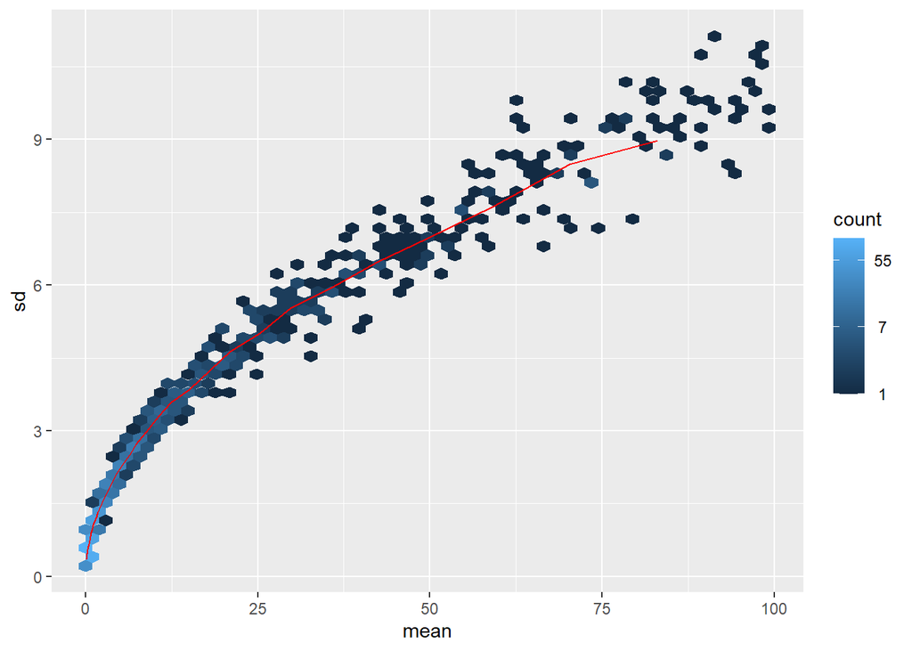

```r
lambda <- 10^seq(from=-1, to=2, length=1000)
cts<- matrix(rpois(1000*100, lambda), ncol=100)
#library(vsn)
meanSdPlot(cts, rank=FALSE)
```

To avoid the analysis depending on the samples with highest count in PCA analysis log of normalized counts +1 is used

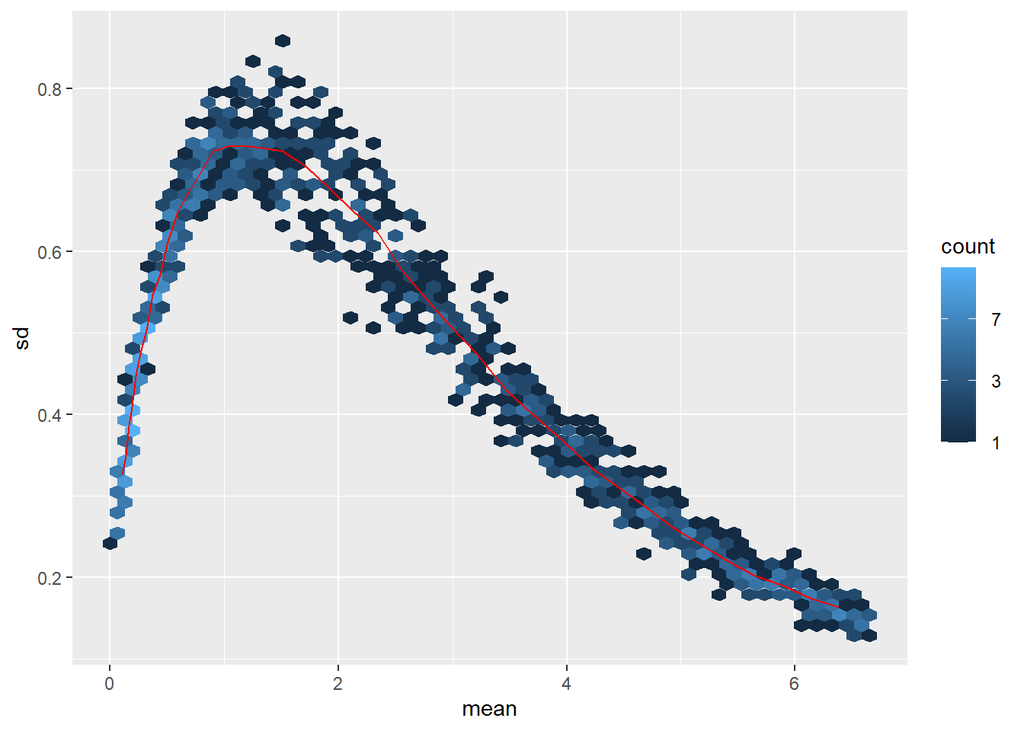

```r
log.cts.one <- log2(cts+1)
meanSdPlot(log.cts.one, ranks=FALSE)
```

But this method amplifies the differences when the values are closer to 0.

**Resolution**

Stabilizing the variance across mean using variance stabilizing transformation (VST) for genes with higher counts or regularized-logarithm transformation (rlog) for genes with lower counts

```r
vsd <- vst(dds, blind=FALSE)
```

```
## using 'avgTxLength' from assays(dds), correcting for library size
```

```r
head(assay(vsd),3)
```

```
##                    SRR1039508 SRR1039509 SRR1039512 SRR1039513 SRR1039516
## ENSG00000000003.14   9.955039   9.679824  10.029543   9.834730  10.305132
## ENSG00000000419.12   9.499733   9.758775   9.625753   9.622084   9.582549
## ENSG00000000457.13   9.228392   9.075867   9.134241   9.243010   9.041568
##                    SRR1039517 SRR1039520 SRR1039521
## ENSG00000000003.14  10.050705  10.189009   9.841193
## ENSG00000000419.12   9.700871   9.494710   9.668934
## ENSG00000000457.13   9.167264   9.264937   9.258735
```

```r
colData(vsd)
```

```
## DataFrame with 8 rows and 5 columns
##                 names    donor     condition     cell      dex
##              <factor> <factor>      <factor> <factor> <factor>
## SRR1039508 SRR1039508  N61311  Untreated      N61311     untrt
## SRR1039509 SRR1039509  N61311  Dexamethasone  N61311     trt
## SRR1039512 SRR1039512  N052611 Untreated      N052611    untrt
## SRR1039513 SRR1039513  N052611 Dexamethasone  N052611    trt
## SRR1039516 SRR1039516  N080611 Untreated      N080611    untrt
## SRR1039517 SRR1039517  N080611 Dexamethasone  N080611    trt
## SRR1039520 SRR1039520  N061011 Untreated      N061011    untrt
## SRR1039521 SRR1039521  N061011 Dexamethasone  N061011    trt
```

```r
rld <- rlog(dds, blind=FALSE)
```

```
## using 'avgTxLength' from assays(dds), correcting for library size
```

```r
head(assay(rld),3)
```

```
##                    SRR1039508 SRR1039509 SRR1039512 SRR1039513 SRR1039516
## ENSG00000000003.14   9.479819   9.174076   9.560600   9.348800   9.852133
## ENSG00000000419.12   8.857583   9.150776   9.002275   8.998053   8.952939
## ENSG00000000457.13   8.352389   8.167048   8.238478   8.368824   8.122727
##                    SRR1039517 SRR1039520 SRR1039521
## ENSG00000000003.14   9.583524   9.729962   9.354836
## ENSG00000000419.12   9.087279   8.852061   9.050919
## ENSG00000000457.13   8.278863   8.395534   8.388116
```

blind = FALSE means that differences between cell lines and treatment (the variables in the design) will not contribute to the expected variance mean trend of the experiment.

fully unsupervised transformation, one can set blind = TRUE

Showing the effect of transformation

```r
#library("dplyr")
#library("ggplot2")
dds <- estimateSizeFactors(dds)
```

```
## using 'avgTxLength' from assays(dds), correcting for library size
```

```r
df <- bind_rows(
as_data_frame(log2(counts(dds, normalized=TRUE)[, 1:2]+1)) %>%
mutate(transformation = "log2(x + 1)"),
as_data_frame(assay(vsd)[, 1:2]) %>% mutate(transformation = "vst"),
as_data_frame(assay(rld)[, 1:2]) %>% mutate(transformation = "rlog"))
```

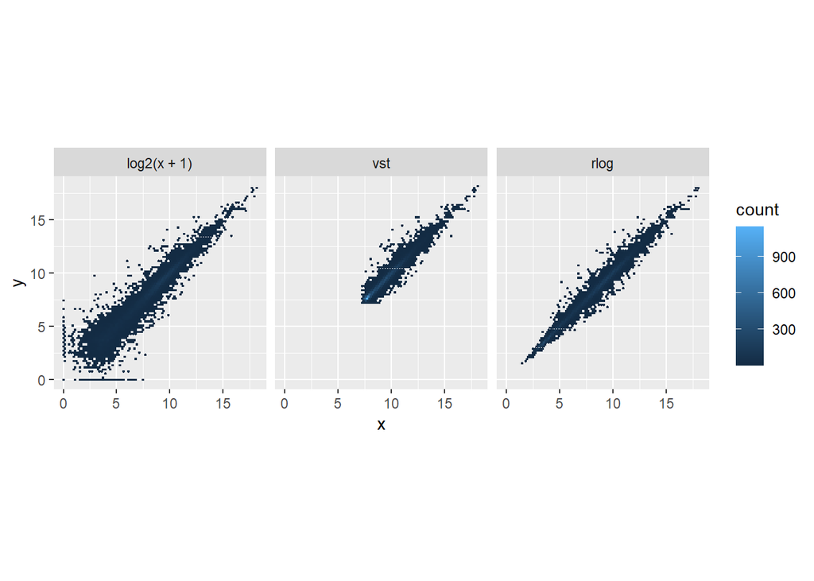

```r
colnames(df)[1:2] <- c("x", "y")
lvls <- c("log2(x + 1)", "vst", "rlog")
df$transformation <- factor(df$transformation, levels=lvls)
ggplot(df, aes(x = x, y = y)) + geom_hex(bins = 80) +
coord_fixed() + facet_grid( . ~ transformation)
```

## Sample Distances

dist()- calculates the Euclidean distance between samples (in rows)

```r
sampleDists <-  dist(t(assay(vsd)))

sampleDists
```

```
##            SRR1039508 SRR1039509 SRR1039512 SRR1039513 SRR1039516 SRR1039517
## SRR1039509   40.90373
## SRR1039512   33.23180   47.08620
## SRR1039513   53.71867   38.14299   43.50686
## SRR1039516   37.05651   50.16491   36.06236   54.88351
## SRR1039517   54.25364   43.59572   49.38590   42.38959   41.47663
## SRR1039520   33.00749   49.19127   30.65509   50.20095   38.47166   53.07066
## SRR1039521   54.09859   38.63401   49.24861   31.59265   55.40045   43.25902
##            SRR1039520
## SRR1039509
## SRR1039512
## SRR1039513
## SRR1039516
## SRR1039517
## SRR1039520
## SRR1039521   44.68459
```

Visualizing the distances using heat maps

[output not shown]

[output not shown]

[output not shown]

[output not shown]

[output not shown]

[output not shown]

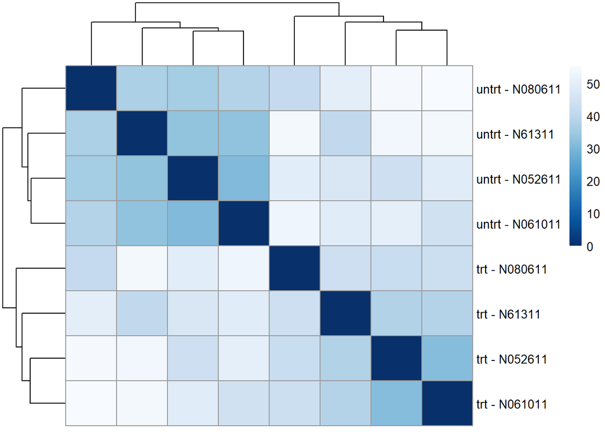

```r
#library(pheatmap)
#library(RColorBrewer)
sampleDistMatrix <- as.matrix( sampleDists )
rownames(sampleDistMatrix) <- paste( vsd$dex, vsd$cell, sep = " - " )
colnames(sampleDistMatrix) <- NULL
colors <- colorRampPalette( rev(brewer.pal(9, "Blues")) )(255)
pheatmap(sampleDistMatrix,
clustering_distance_rows = sampleDists,
clustering_distance_cols = sampleDists,
col = colors)
```

2. Calculating the distances using Poisson Distance

This method gets variance of counts into consideration when calculating the distance between samples

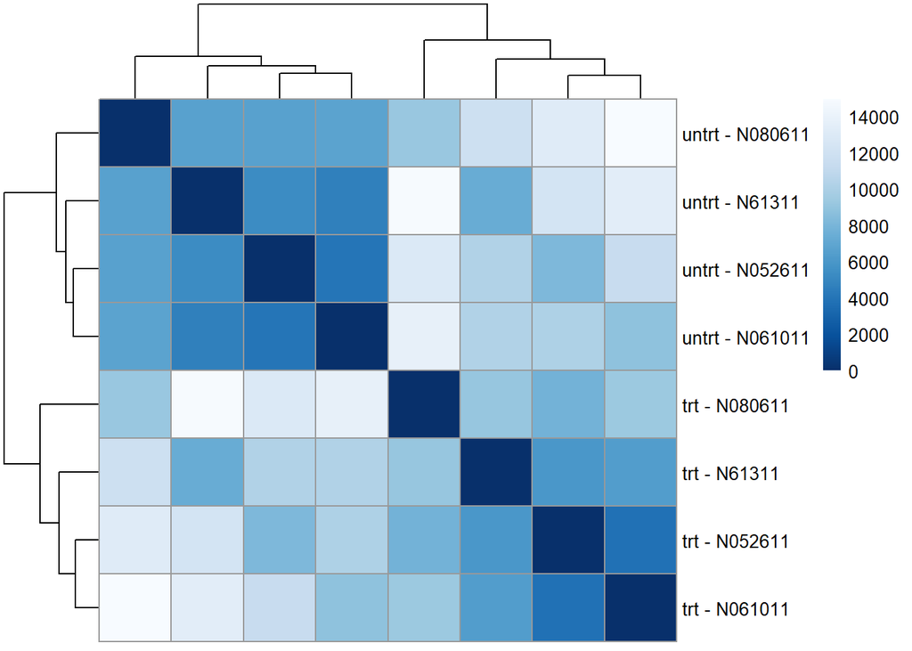

```r
#library(PoiClaClu)
poisd <- PoissonDistance(t(counts(dds)))

samplePoisDistMatrix <- as.matrix( poisd$dd )
rownames(samplePoisDistMatrix) <- paste( dds$dex, dds$cell, sep=" - " )
colnames(samplePoisDistMatrix) <- NULL
pheatmap(samplePoisDistMatrix,
clustering_distance_rows = poisd$dd,
clustering_distance_cols = poisd$dd,
col = colors)
```

3. 1. PCA plot

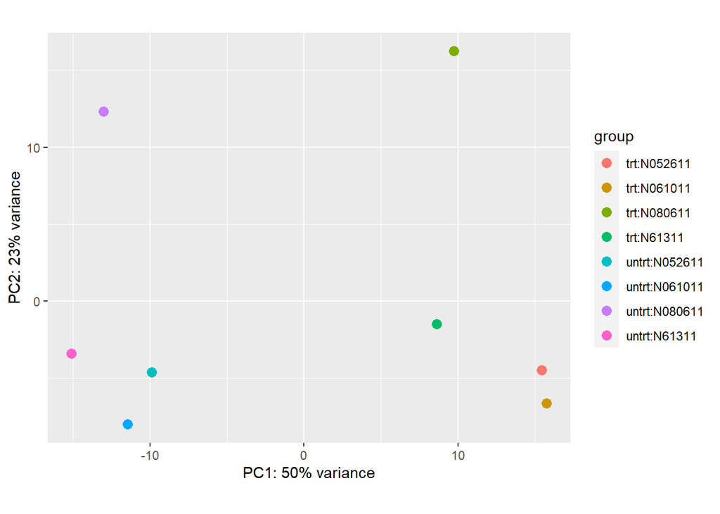

```r
plotPCA(vsd, intgroup = c("dex", "cell"))
```

2. PCA plot using ggplot

```r
pcaData <- plotPCA(vsd, intgroup = c( "dex", "cell"), returnData = TRUE)
pcaData
```

```
##                   PC1       PC2         group   dex    cell       name
## SRR1039508 -15.118076 -3.382384  untrt:N61311 untrt  N61311 SRR1039508
## SRR1039509   8.607821 -1.494647    trt:N61311   trt  N61311 SRR1039509
## SRR1039512  -9.910162 -4.622986 untrt:N052611 untrt N052611 SRR1039512
## SRR1039513  15.434646 -4.461734   trt:N052611   trt N052611 SRR1039513
## SRR1039516 -13.041969 12.323955 untrt:N080611 untrt N080611 SRR1039516
## SRR1039517   9.732468 16.252620   trt:N080611   trt N080611 SRR1039517
## SRR1039520 -11.468348 -7.994807 untrt:N061011 untrt N061011 SRR1039520
## SRR1039521  15.763619 -6.620017   trt:N061011   trt N061011 SRR1039521
```

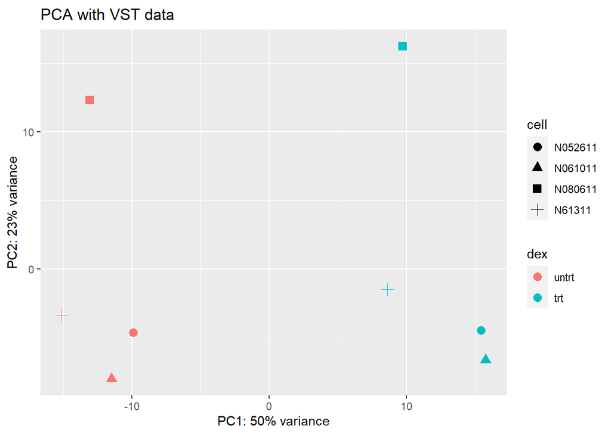

```r
percentVar <- round(100 * attr(pcaData, "percentVar"))

ggplot(pcaData, aes(x = PC1, y = PC2, color = dex, shape = cell)) +
geom_point(size =3) +
xlab(paste0("PC1: ", percentVar[1], "% variance")) +
ylab(paste0("PC2: ", percentVar[2], "% variance")) +
coord_fixed() +
ggtitle("PCA with VST data")
```

c) PCA plot using Generalized PCA

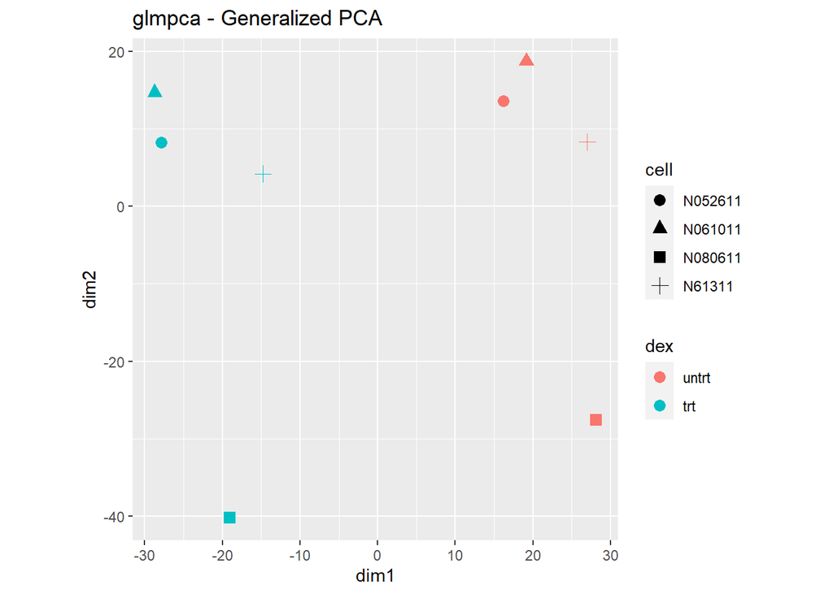

```r
#library("glmpca")
gpca <- glmpca(counts(dds), L=2)
gpca.dat <- gpca$factors
gpca.dat$dex <- dds$dex
gpca.dat$cell <- dds$cell

ggplot(gpca.dat, aes(x = dim1, y = dim2, color = dex, shape = cell)) +
geom_point(size =3) + coord_fixed() + ggtitle("glmpca - Generalized PCA")
```

4. a) Multidimensional scaling (MDS) plots.

This is done when no matrix data is available but matrix of distance is available.

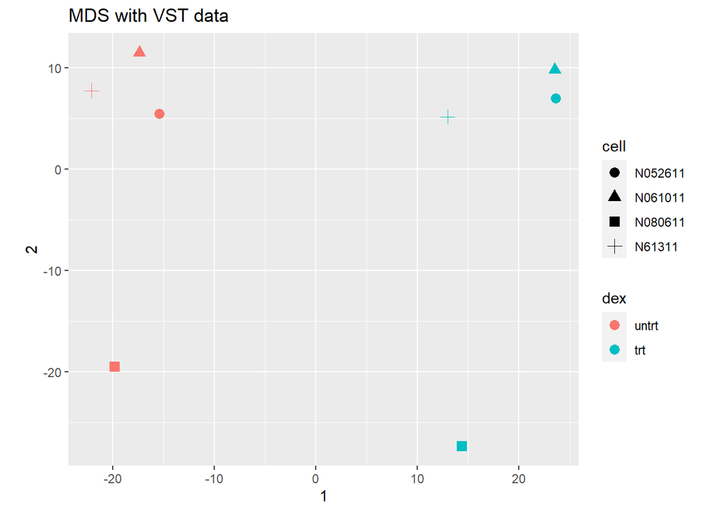

```r
mds <- as.data.frame(colData(vsd)) %>%
cbind(cmdscale(sampleDistMatrix))
ggplot(mds, aes(x = `1`, y = `2`, color = dex, shape = cell)) +
geom_point(size = 3) + coord_fixed() + ggtitle("MDS with VST data")
```

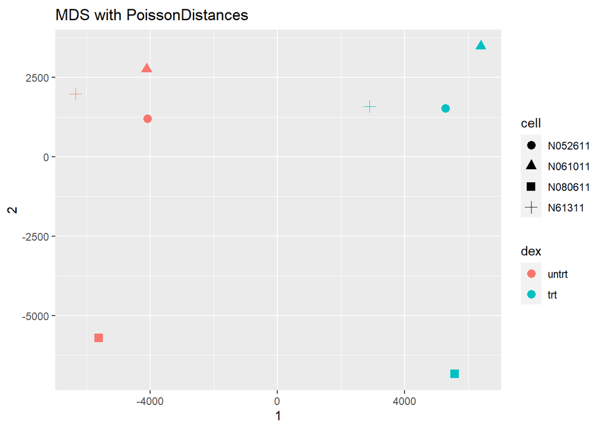

```r
mdsPois <- as.data.frame(colData(dds)) %>%
cbind(cmdscale(samplePoisDistMatrix))
ggplot(mdsPois, aes(x = `1`, y = `2`, color = dex, shape = cell)) +
geom_point(size = 3) + coord_fixed() + ggtitle("MDS with PoissonDistances")
```

# Differential Expression Analysis

```r
dds <-DESeq(dds)
res <- results(dds)
res <- results(dds, contrast=c("dex","trt","untrt"))
mcols(res, use.names = TRUE)
```

```
## DataFrame with 6 rows and 2 columns
##                        type                               description
##                 <character>                               <character>
## baseMean       intermediate mean of normalized counts for all samples
## log2FoldChange      results  log2 fold change (MLE): dex trt vs untrt
## lfcSE               results          standard error: dex trt vs untrt
## stat                results          Wald statistic: dex trt vs untrt
## pvalue              results       Wald test p-value: dex trt vs untrt
## padj                results                      BH adjusted p-values
```

```r
summary(res)
```

```
##
## out of 17213 with nonzero total read count
## adjusted p-value < 0.1
## LFC > 0 (up)       : 2391, 14%
## LFC < 0 (down)     : 2015, 12%
## outliers [1]       : 0, 0%
## low counts [2]     : 1335, 7.8%
## (mean count < 12)
## [1] see 'cooksCutoff' argument of ?results
## [2] see 'independentFiltering' argument of ?results
```

```r
res.05 <- results(dds, alpha = 0.05)
table(res.05$padj < 0.05)
```

```
##
## FALSE  TRUE
## 12931  3614
```

```r
resLFC1 <- results(dds, lfcThreshold=1)
table(resLFC1$padj < 0.1)
```

```
##
## FALSE  TRUE
## 17000   213
```

## Other Comparisons

```r
results(dds, contrast = c("cell", "N061011", "N61311"))
```

```
## log2 fold change (MLE): cell N061011 vs N61311
## Wald test p-value: cell N061011 vs N61311
## DataFrame with 17213 rows and 6 columns
##                     baseMean log2FoldChange     lfcSE      stat      pvalue
##                    <numeric>      <numeric> <numeric> <numeric>   <numeric>
## ENSG00000000003.14  740.0279      0.2723899  0.151496  1.797997 7.21775e-02
## ENSG00000000419.12  511.7064     -0.0709314  0.181112 -0.391643 6.95322e-01
## ENSG00000000457.13  314.1800      0.1814239  0.220967  0.821044 4.11621e-01
## ENSG00000000460.16   79.8027     -0.1182625  0.433314 -0.272926 7.84910e-01
## ENSG00000000971.15 5715.4351      0.8232834  0.126328  6.517038 7.17094e-11
## ...                      ...            ...       ...       ...         ...
## ENSG00000285953.1    29.5674      1.3032317  0.910375  1.431533   0.1522776
## ENSG00000285967.1   181.1566     -0.5349660  0.255380 -2.094788   0.0361899
## ENSG00000285976.1   875.4883     -0.0933780  0.203201 -0.459534   0.6458504
## ENSG00000285979.1    38.3528      0.0602748  0.499937  0.120565   0.9040357
## ENSG00000285991.1    11.2795     -0.8779051  1.022392 -0.858677   0.3905186
##                           padj
##                      <numeric>
## ENSG00000000003.14 3.63097e-01
## ENSG00000000419.12 9.32666e-01
## ENSG00000000457.13 8.03335e-01
## ENSG00000000460.16 9.57150e-01
## ENSG00000000971.15 9.36681e-09
## ...                        ...
## ENSG00000285953.1     0.531552
## ENSG00000285967.1     0.240175
## ENSG00000285976.1     0.915761
## ENSG00000285979.1     0.981260
## ENSG00000285991.1           NA
```

## Multiple testing

```r
sum(res$pvalue < 0.05, na.rm=TRUE)
```

```
## [1] 5114
```

```r
sum(!is.na(res$pvalue))
```

```
## [1] 17213
```

```r
sum(res$padj < 0.1, na.rm=TRUE)
```

```
## [1] 4406
```

```r
resSig <- subset(res, padj < 0.1)
head(resSig[ order(resSig$log2FoldChange), ])
```

```
## log2 fold change (MLE): dex trt vs untrt
## Wald test p-value: dex trt vs untrt
## DataFrame with 6 rows and 6 columns
##                    baseMean log2FoldChange     lfcSE      stat      pvalue
##                   <numeric>      <numeric> <numeric> <numeric>   <numeric>
## ENSG00000216490.3   42.3221       -5.72557  1.473955  -3.88449 1.02544e-04
## ENSG00000267339.5   30.5726       -5.39815  0.762256  -7.08181 1.42286e-12
## ENSG00000146006.7   61.6436       -4.48984  0.653856  -6.86671 6.56984e-12
## ENSG00000108700.4   14.6427       -4.07467  0.920914  -4.42460 9.66217e-06
## ENSG00000155897.9   23.9852       -3.87371  0.819770  -4.72537 2.29699e-06
## ENSG00000019186.9   14.1350       -3.78784  0.941953  -4.02126 5.78876e-05
##                          padj
##                     <numeric>
## ENSG00000216490.3 9.03456e-04
## ENSG00000267339.5 4.50044e-11
## ENSG00000146006.7 1.90011e-10
## ENSG00000108700.4 1.10451e-04
## ENSG00000155897.9 3.01418e-05
## ENSG00000019186.9 5.46457e-04
```

```r
head(resSig[ order(resSig$log2FoldChange, decreasing = TRUE), ])
```

```
## log2 fold change (MLE): dex trt vs untrt
## Wald test p-value: dex trt vs untrt
## DataFrame with 6 rows and 6 columns
##                     baseMean log2FoldChange     lfcSE      stat      pvalue
##                    <numeric>      <numeric> <numeric> <numeric>   <numeric>
## ENSG00000254692.1    62.1767       10.20377  3.377058   3.02150 2.51528e-03
## ENSG00000179593.15   67.0087        9.50238  1.072968   8.85617 8.28122e-19
## ENSG00000268173.3    46.4506        8.40331  3.385052   2.48248 1.30473e-02
## ENSG00000224712.12   35.5665        7.16562  2.164750   3.31014 9.32501e-04
## ENSG00000109906.13  437.7787        6.37434  0.312431  20.40238 1.59260e-92
## ENSG00000257663.1    24.3731        6.34276  2.095415   3.02697 2.47019e-03
##                           padj
##                      <numeric>
## ENSG00000254692.1  1.42685e-02
## ENSG00000179593.15 4.91604e-17
## ENSG00000268173.3  5.57494e-02
## ENSG00000224712.12 6.11323e-03
## ENSG00000109906.13 2.52874e-89
## ENSG00000257663.1  1.40429e-02
```

## Plotting Results

1. Counts plot
1. Plotting using plotCounts

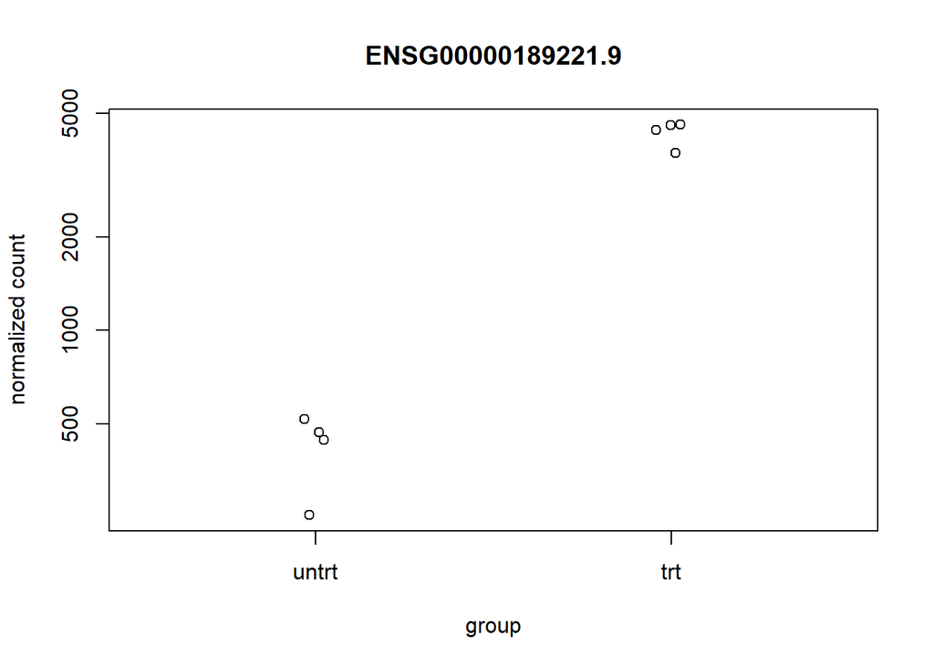

```r
topGene <- rownames(res)[which.min(res$padj)]
plotCounts(dds, gene = topGene, intgroup=c("dex"))
```

b) Plotting using ggplot

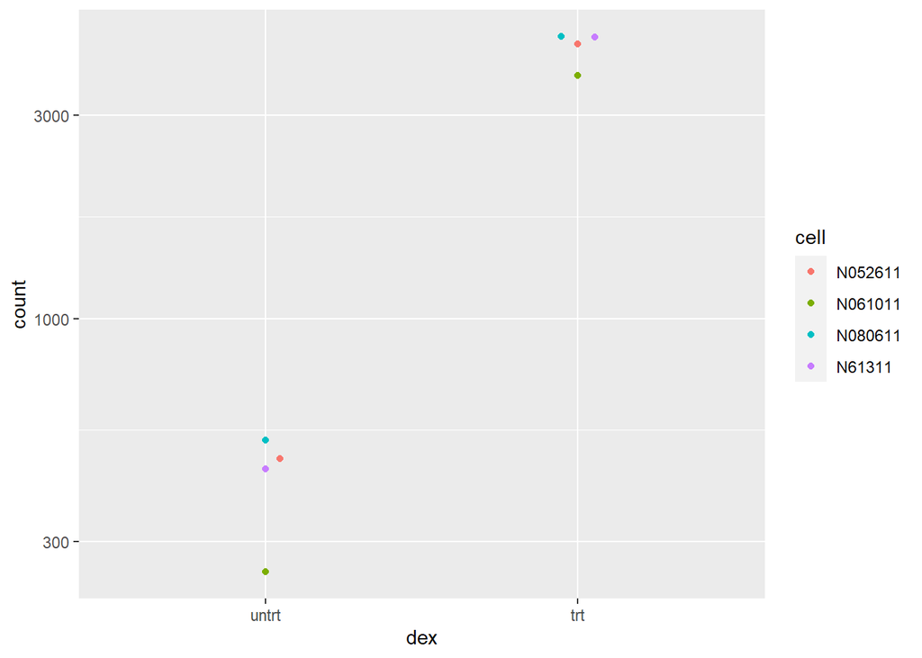

```r
#library("ggbeeswarm")
geneCounts <- plotCounts(dds, gene = topGene, intgroup = c("dex","cell"),
returnData = TRUE)
ggplot(geneCounts, aes(x = dex, y = count, color = cell)) +
scale_y_log10() + geom_beeswarm(cex = 3)
```

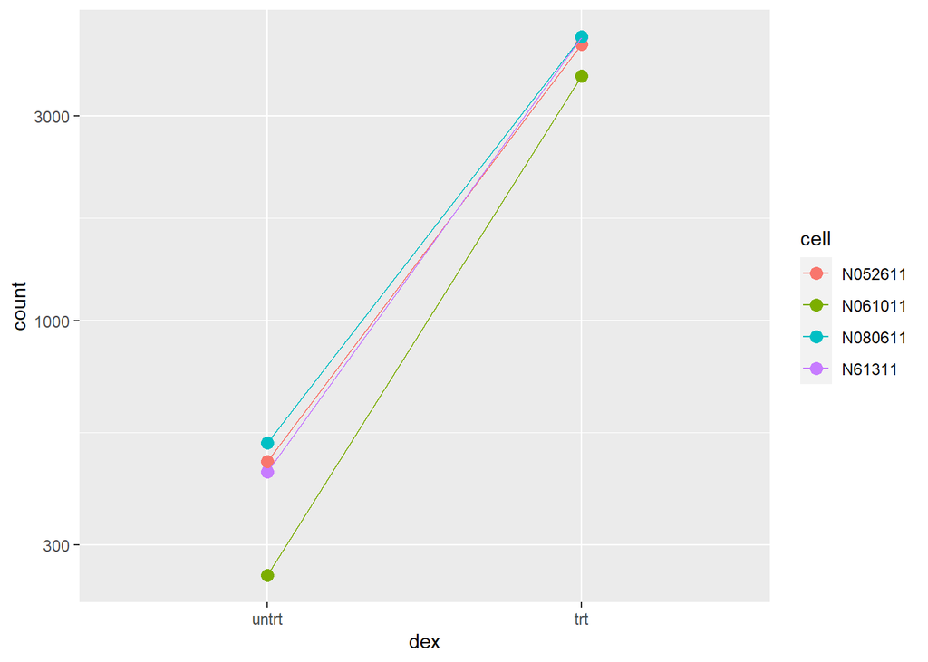

```r
ggplot(geneCounts, aes(x = dex, y = count, color = cell, group = cell)) +
scale_y_log10() + geom_point(size = 3) + geom_line()
```

2. MA-plot

MA-plot provides a useful overview for the distribution of the estimated coefficients in the model, e.g. the comparisons of interest, across all genes.

```r
#library("apeglm")
resultsNames(dds)
```

```
## [1] "Intercept"               "cell_N061011_vs_N052611"
## [3] "cell_N080611_vs_N052611" "cell_N61311_vs_N052611"
## [5] "dex_trt_vs_untrt"
```

```r
res <- lfcShrink(dds, coef="dex_trt_vs_untrt", type="apeglm")
```

```
## using 'apeglm' for LFC shrinkage. If used in published research, please cite:
##     Zhu, A., Ibrahim, J.G., Love, M.I. (2018) Heavy-tailed prior distributions for
##     sequence count data: removing the noise and preserving large differences.
##     Bioinformatics. https://doi.org/10.1093/bioinformatics/bty895
```

[figure not shown]

```r
plotMA(res, ylim = c(-5, 5))
```

The above plot without removing the noisy log2 fold change

[figure not shown]

```r
res.noshr <- results(dds, name="dex_trt_vs_untrt")
plotMA(res.noshr, ylim = c(-5, 5))
```

Labeling individual points

[figure not shown]

```r
plotMA(res, ylim = c(-5,5))
topGene <- rownames(res)[which.min(res$padj)]
with(res[topGene, ], {
points(baseMean, log2FoldChange, col="dodgerblue", cex=2, lwd=2)
text(baseMean, log2FoldChange, topGene, pos=2, col="dodgerblue")
})
```

3. Histogram

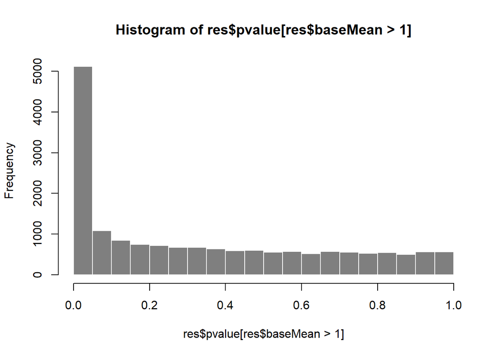

```r
hist(res$pvalue[res$baseMean > 1], breaks = 0:20/20,
col = "grey50", border = "white")
```

# Gene Clustering

eg. Plotting 20 genes with the highest variance across samples

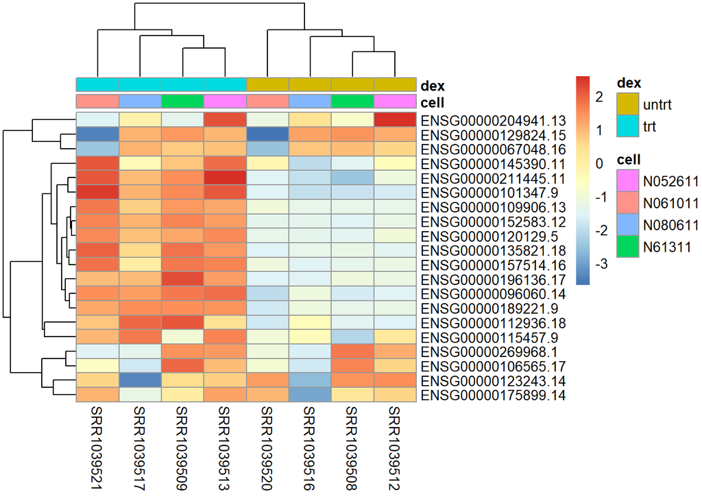

```r
#library("genefilter")
topVarGenes <- head(order(rowVars(assay(vsd)), decreasing = TRUE), 20)

mat <- assay(vsd)[ topVarGenes, ]
mat <- mat - rowMeans(mat)
anno <- as.data.frame(colData(vsd)[, c("cell","dex")])
pheatmap(mat, annotation_col = anno)
```

# Independant filtering

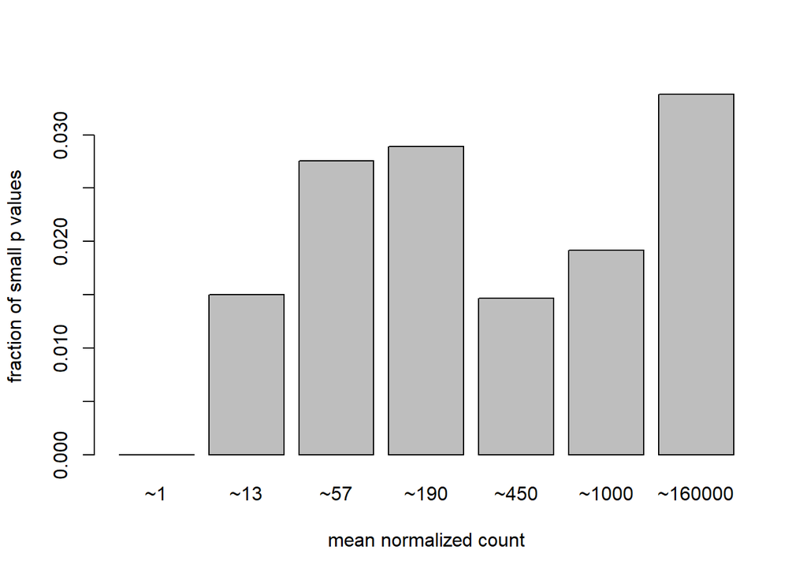

```r
qs <- c(0, quantile(resLFC1$baseMean[resLFC1$baseMean > 0], 0:6/6))
bins <- cut(resLFC1$baseMean, qs)
levels(bins) <- paste0("~", round(signif((qs[-1] + qs[-length(qs)])/2, 2)))
fractionSig <- tapply(resLFC1$pvalue, bins, function(p)
mean(p < .05, na.rm = TRUE))
barplot(fractionSig, xlab = "mean normalized count",
ylab = "fraction of small p values")
```

# Independant hypothesis weighing

The idea of p value filtering is to weight hypotheses to optimize power. It can be done as shown below.

```r
#library("IHW")
res.ihw <- results(dds, filterFun=ihw)
```

# Annotating and exporting results

library(org.Hs.eg.db) is the organism annotation package (“org”) for Homo sapiens (“Hs”), organized as an AnnotationDbi database package (“db”), using Entrez Gene IDs (“eg”) as primary key

```r
#library(AnnotationDbi)
#library(org.Hs.eg.db)
columns(org.Hs.eg.db)
```

```
##  [1] "ACCNUM"       "ALIAS"        "ENSEMBL"      "ENSEMBLPROT"  "ENSEMBLTRANS"
##  [6] "ENTREZID"     "ENZYME"       "EVIDENCE"     "EVIDENCEALL"  "GENENAME"
## [11] "GO"           "GOALL"        "IPI"          "MAP"          "OMIM"
## [16] "ONTOLOGY"     "ONTOLOGYALL"  "PATH"         "PFAM"         "PMID"
## [21] "PROSITE"      "REFSEQ"       "SYMBOL"       "UCSCKG"       "UNIGENE"
## [26] "UNIPROT"
```

mapIds()- add individual columns to result table

1. Add genesymbol

```r
ens.str <- substr(rownames(res), 1, 15)
res$symbol <- mapIds(org.Hs.eg.db,
keys=ens.str,
column="SYMBOL",
keytype="ENSEMBL",
multiVals="first")
res$entrez <- mapIds(org.Hs.eg.db,
keys=ens.str,
column="ENTREZID",
keytype="ENSEMBL",
multiVals="first")
```

2. add entrez id

```r
res$entrez <- mapIds(org.Hs.eg.db,
keys=ens.str,
column="ENTREZID",
keytype="ENSEMBL",
multiVals="first")
```

The results

```r
resOrdered <- res[order(res$pvalue),]
head(resOrdered)
```

```
## log2 fold change (MAP): dex trt vs untrt
## Wald test p-value: dex trt vs untrt
## DataFrame with 6 rows and 7 columns
##                     baseMean log2FoldChange     lfcSE       pvalue         padj
##                    <numeric>      <numeric> <numeric>    <numeric>    <numeric>
## ENSG00000189221.9   2372.073        3.38516  0.136554 4.35902e-138 6.92125e-134
## ENSG00000120129.5   3418.738        2.96240  0.121135 6.63138e-134 5.26466e-130
## ENSG00000101347.9  14114.665        3.73756  0.158401 1.96622e-126 1.04066e-122
## ENSG00000152583.12   973.968        4.48382  0.200723 9.24093e-114 3.66819e-110
## ENSG00000196136.17  2709.508        3.23242  0.144979 2.03125e-112 6.45045e-109
## ENSG00000211445.11 12509.543        3.75476  0.171034 2.61152e-110 6.91096e-107
##                         symbol      entrez
##                    <character> <character>
## ENSG00000189221.9         MAOA        4128
## ENSG00000120129.5        DUSP1        1843
## ENSG00000101347.9       SAMHD1       25939
## ENSG00000152583.12     SPARCL1        8404
## ENSG00000196136.17    SERPINA3          12
## ENSG00000211445.11        GPX3        2878
```

# Exporting Results1)

1. Saving as data frames

```r
resOrderedDF <- as.data.frame(resOrdered)[1:100, ]
write.csv(resOrderedDF, file = "Results/RNASEQ_results.csv")
```

2. Saving as dynamic html with external data base links, gene identifies and box plots withnormalized counts

```r
#library(ReportingTools)
htmlRep <- HTMLReport(shorthname= "report", title = "My report", )

htmlRep <- HTMLReport(shortName="report", title="My report",
reportDirectory="./report")
publish(resOrderedDF, htmlRep)
url <- finish(htmlRep)
browseURL(url)
```

# Plotting fold changes in genomic space

```r
resGR <- lfcShrink(dds=dds, coef="dex_trt_vs_untrt", type="apeglm", format="GRanges")
```

```
## using 'apeglm' for LFC shrinkage. If used in published research, please cite:
##     Zhu, A., Ibrahim, J.G., Love, M.I. (2018) Heavy-tailed prior distributions for
##     sequence count data: removing the noise and preserving large differences.
##     Bioinformatics. https://doi.org/10.1093/bioinformatics/bty895
```

```r
resGR
```

```
## GRanges object with 17213 ranges and 5 metadata columns:
##                      seqnames              ranges strand |  baseMean
##                         <Rle>           <IRanges>  <Rle> | <numeric>
##   ENSG00000000003.14     chrX 100627109-100639991      - |  740.0279
##   ENSG00000000419.12    chr20   50934867-50958555      - |  511.7064
##   ENSG00000000457.13     chr1 169849631-169894267      - |  314.1800
##   ENSG00000000460.16     chr1 169662007-169854080      + |   79.8027
##   ENSG00000000971.15     chr1 196651878-196747504      + | 5715.4351
##                  ...      ...                 ...    ... .       ...
##    ENSG00000285953.1     chr7   92131774-92245924      - |   29.5674
##    ENSG00000285967.1     chr5   36864425-36876700      - |  181.1566
##    ENSG00000285976.1     chr6   63572012-63583587      + |  875.4883
##    ENSG00000285979.1    chr16   57177349-57181390      + |   38.3528
##    ENSG00000285991.1     chr6 149817937-149896011      - |   11.2795
##                      log2FoldChange     lfcSE      pvalue        padj
##                           <numeric> <numeric>   <numeric>   <numeric>
##   ENSG00000000003.14     -0.3393833 0.1053997 6.22688e-04 4.34023e-03
##   ENSG00000000419.12      0.1786105 0.1215031 1.10264e-01 2.80439e-01
##   ENSG00000000457.13      0.0279248 0.1397346 8.21636e-01 9.17629e-01
##   ENSG00000000460.16     -0.0598187 0.2240446 7.00707e-01 8.51654e-01
##   ENSG00000000971.15      0.4246515 0.0890367 6.19271e-07 9.10444e-06
##                  ...            ...       ...         ...         ...
##    ENSG00000285953.1      -1.175070  0.980069  0.00365435    0.019530
##    ENSG00000285967.1      -0.261943  0.170208  0.07101578    0.204421
##    ENSG00000285976.1       0.225925  0.137359  0.06632334    0.194274
##    ENSG00000285979.1       0.160836  0.258111  0.33267736    0.570883
##    ENSG00000285991.1      -0.017111  0.289884  0.87437017          NA
##   -------
##   seqinfo: 25 sequences (1 circular) from hg38 genome
```

```r
ens.str <- substr(names(resGR), 1, 15)
resGR$symbol <- mapIds(org.Hs.eg.db, ens.str, "SYMBOL", "ENSEMBL")
#library(Gviz)


window <- resGR[topGene] + 1e6
strand(window) <- "*"
resGRsub <- resGR[resGR %over% window]
naOrDup <- is.na(resGRsub$symbol) | duplicated(resGRsub$symbol)
resGRsub$group <- ifelse(naOrDup, names(resGRsub), resGRsub$symbol)
```

Specifying a window of 1 million base pairs upstream and downstream from the gene with the smallest p value.

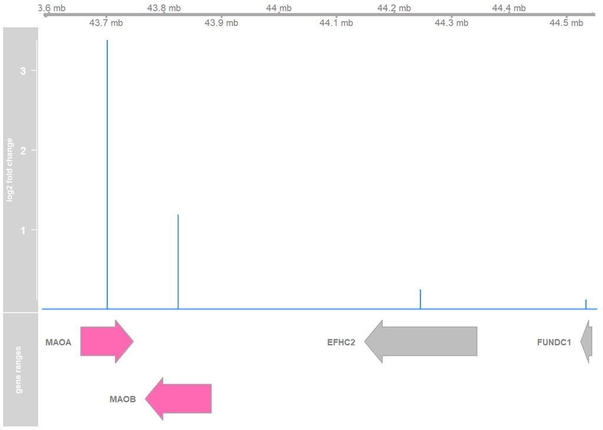

```r
#library("Gviz")
window <- resGR[topGene] + 1e6
strand(window) <- "*"
resGRsub <- resGR[resGR %over% window]
naOrDup <- is.na(resGRsub$symbol) | duplicated(resGRsub$symbol)
resGRsub$group <- ifelse(naOrDup, names(resGRsub), resGRsub$symbol)

status <- factor(ifelse(resGRsub$padj < 0.05 & !is.na(resGRsub$padj),
"sig", "notsig"))

options(ucscChromosomeNames = FALSE)
g <- GenomeAxisTrack()
a <- AnnotationTrack(resGRsub, name = "gene ranges", feature = status)
d <- DataTrack(resGRsub, data = "log2FoldChange", baseline = 0,
type = "h", name = "log2 fold change", strand = "+")
plotTracks(list(g, d, a), groupAnnotation = "group",
notsig = "grey", sig = "hotpink")
```

# Using SVA with DESeq2

Recovering an batch effects by obtaining a matrix of normalized counts for which the average count across the samples is larger than 1

```r
dat <- counts(dds, normalized = TRUE)
idx <- rowMeans(dat) > 1
dat <- dat[idx, ]
mod <- model.matrix(~ dex, colData(dds))
mod0 <- model.matrix(~ 1, colData(dds))
svseq <- svaseq(dat, mod, mod0, n.sv = 2)
```

```
## Number of significant surrogate variables is:  2
## Iteration (out of 5 ):1  2  3  4  5
```

```r
svseq$sv
```

```
##            [,1]        [,2]
## [1,]  0.1988344 -0.37235015
## [2,]  0.2090464 -0.39198816
## [3,]  0.1296916 -0.20257130
## [4,]  0.1037116 -0.26903410
## [5,]  0.2802197  0.52777925
## [6,]  0.2857210  0.55074910
## [7,] -0.6165189  0.08193760
## [8,] -0.5907058  0.07547776
```

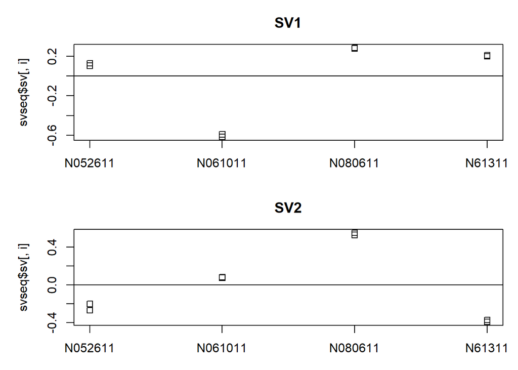

```r
par(mfrow = c(2, 1), mar = c(3,5,3,1))
for (i in 1:2) {
stripchart(svseq$sv[, i] ~ dds$cell, vertical = TRUE, main = paste0("SV", i))
abline(h = 0)
}
```

```r
ddssva <- dds
ddssva$SV1 <- svseq$sv[,1]
ddssva$SV2 <- svseq$sv[,2]
design(ddssva) <- ~ SV1 + SV2 + dex
```

# Usng RUV with DESeq2

Detecting hidden batch effects RUVg()- Estimates factors of unwanted variation

```r
#library(RUVSeq)
set <- newSeqExpressionSet(counts(dds))
idx <- rowSums(counts(set) > 5) >= 2
set <- set[idx, ]
set <- betweenLaneNormalization(set, which="upper")
not.sig <- rownames(res)[which(res$pvalue > .1)]
empirical <- rownames(set)[ rownames(set) %in% not.sig ]
set <- RUVg(set, empirical, k=2)
pData(set)
```

```
##                    W_1          W_2
## SRR1039508 -0.26480115  0.427821738
## SRR1039509 -0.27905940  0.520669204
## SRR1039512  0.01703463  0.022414633
## SRR1039513 -0.16934232  0.050694348
## SRR1039516  0.58934030  0.012108480
## SRR1039517  0.59535084  0.007858801
## SRR1039520 -0.21305825 -0.511830615
## SRR1039521 -0.27546464 -0.529736589
```

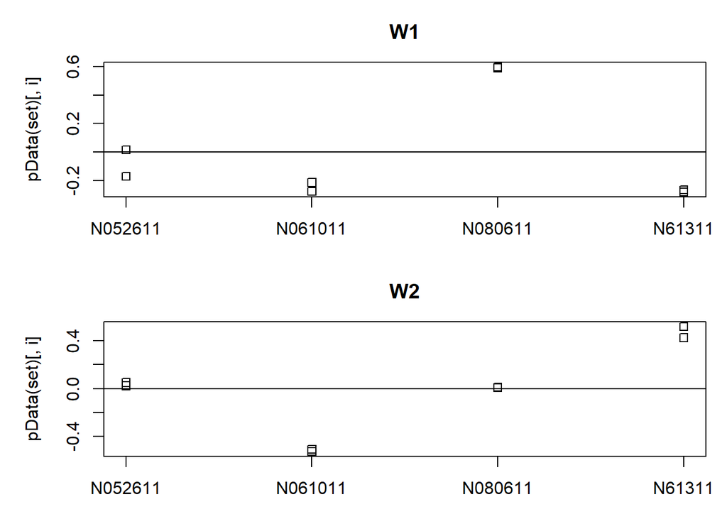

```r
par(mfrow = c(2, 1), mar = c(3,5,3,1))
for (i in 1:2) {
stripchart(pData(set)[, i] ~ dds$cell, vertical = TRUE, main = paste0("W",
i))
abline(h = 0)
}
```

Above unwanted variation plotted over cell line is added to DESeqData Set and design

```r
ddsruv <- dds
ddsruv$W1 <- set$W_1
ddsruv$W2 <- set$W_2
design(ddsruv) <- ~ W1 + W2 + dex
```

# Time course experiments

```r
# library(fission)
data (fission)
ddsTC <- DESeqDataSet(fission, ~ strain + minute + strain:minute)
```

Remove the strain specific differences over time in fission data set

```r
ddsTC <- DESeq(ddsTC, test="LRT", reduced = ~ strain + minute)
resTC <- results(ddsTC)
resTC$symbol <- mcols(ddsTC)$symbol
head(resTC[order(resTC$padj),], 4)
```

```
## log2 fold change (MLE): strainmut.minute180
## LRT p-value: '~ strain + minute + strain:minute' vs '~ strain + minute'
## DataFrame with 4 rows and 7 columns
##               baseMean log2FoldChange     lfcSE      stat      pvalue
##              <numeric>      <numeric> <numeric> <numeric>   <numeric>
## SPBC2F12.09c   174.671     -2.6567195  0.752261   97.2834 1.97415e-19
## SPAC1002.18    444.505     -0.0509321  0.204299   56.9536 5.16955e-11
## SPAC1002.19    336.373     -0.3927490  0.573494   43.5339 2.87980e-08
## SPAC1002.17c   261.773     -1.1387648  0.606129   39.3158 2.05137e-07
##                     padj      symbol
##                <numeric> <character>
## SPBC2F12.09c 1.33453e-15       atf21
## SPAC1002.18  1.74731e-07        urg3
## SPAC1002.19  6.48916e-05        urg1
## SPAC1002.17c 3.46682e-04        urg2
```

Model the counts as a smooth function over time and to include an interaction term of the condition with smooth function

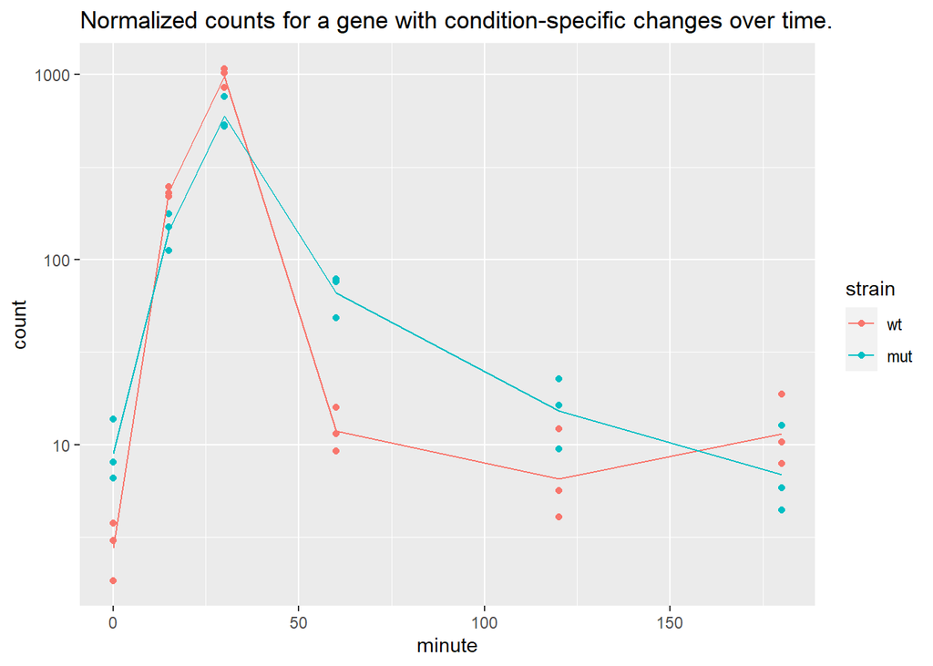

```r
fiss <- plotCounts(ddsTC, which.min(resTC$padj),
intgroup = c("minute","strain"), returnData = TRUE)
fiss$minute <- as.numeric(as.character(fiss$minute))
ggplot(fiss,
aes(x = minute, y = count, color = strain, group = strain)) +
geom_point() + stat_summary(fun.y=mean, geom="line") +
scale_y_log10()+
  labs(title="Normalized counts for a gene with condition-specific changes over time.")
```

Wald test for the log2 fold changes at individual time points can be investigated sing the test argument to results

```r
resultsNames(ddsTC)
```

```
##  [1] "Intercept"           "strain_mut_vs_wt"    "minute_15_vs_0"
##  [4] "minute_30_vs_0"      "minute_60_vs_0"      "minute_120_vs_0"
##  [7] "minute_180_vs_0"     "strainmut.minute15"  "strainmut.minute30"
## [10] "strainmut.minute60"  "strainmut.minute120" "strainmut.minute180"
```

```r
res30 <- results(ddsTC, name="strainmut.minute30", test="Wald")
res30[which.min(resTC$padj),]
```

```
## log2 fold change (MLE): strainmut.minute30
## Wald test p-value: strainmut.minute30
## DataFrame with 1 row and 6 columns
##               baseMean log2FoldChange     lfcSE      stat      pvalue      padj
##              <numeric>      <numeric> <numeric> <numeric>   <numeric> <numeric>
## SPBC2F12.09c   174.671       -2.60047  0.634343  -4.09947 4.14099e-05  0.279931
```

Clustering significant genes by their profiles

```r
betas <- coef(ddsTC)
colnames(betas)
```

```
##  [1] "Intercept"           "strain_mut_vs_wt"    "minute_15_vs_0"
##  [4] "minute_30_vs_0"      "minute_60_vs_0"      "minute_120_vs_0"
##  [7] "minute_180_vs_0"     "strainmut.minute15"  "strainmut.minute30"
## [10] "strainmut.minute60"  "strainmut.minute120" "strainmut.minute180"
```

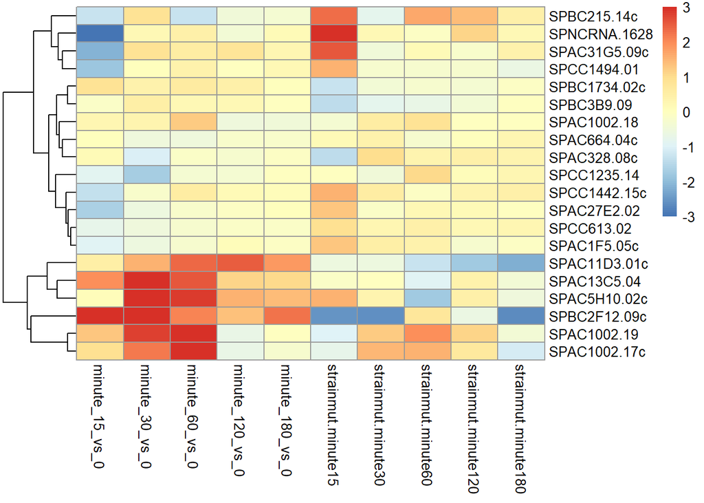

```r
topGenes <- head(order(resTC$padj),20)
mat <- betas[topGenes, -c(1,2)]
thr <- 3
mat[mat < -thr] <- -thr
mat[mat > thr] <- thr
pheatmap(mat, breaks=seq(from=-thr, to=thr, length=101),
cluster_col=FALSE)
```